## A Brief Case Study: Gender Research and the Role of Feminist Theory (Chacamool presentation)

Here we provide the code used to generate the figures in the presentation. This document is written is [rmarkdown](http://rmarkdown.rstudio.com/) and can be rendered into an HTML file containing the results of the analysis using `rmarkdown::render("chacmool.rmd")` or if you are using [RStudio](http://www.rstudio.com/) (as we do), then the “Knit” command (Ctrl+Shift+K) will render the document and display a preview of it.

The data can be obtained freely from http://dfr.jstor.org/ and are included here in the ‘data’ folder

```r
knitr::opts_chunk$set(message=FALSE, warning=FALSE)
# If you don't already have JSTORr, then  you need  to
# download and install the package (do this only once ever per computer)
# uncomment and run the next two lines:
# library(devtools) # Windows users need Rtools, OSX users need XCode
# install_github("benmarwick/JSTORr")
library(JSTORr)
```

```r
# The data are included here with permission from DFR

# American Antiquity data
load("data/unpack1grams.rdata")

# SAA guide says 15 cm width max for figs, JPEG, colour ok
```

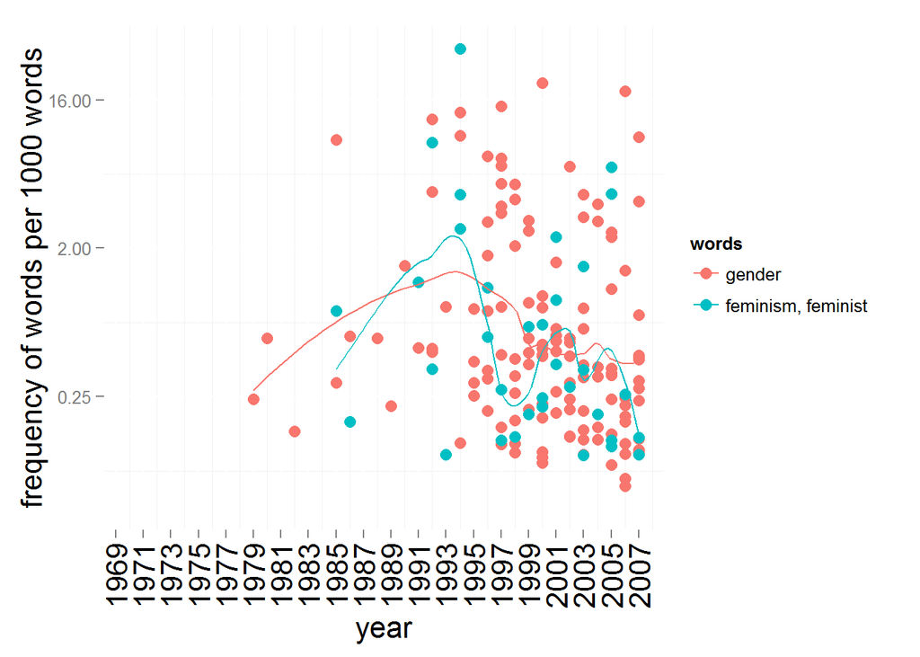

```r
plot1 <- JSTOR_2words(unpack1grams, "gender", c("feminism", "feminist"), span = 0.48, yearfrom = 1970, yearto = 2007)
plot1$plot +
  scale_y_continuous(trans=log2_trans()) +
   theme(axis.title.x = element_text(size = 16, colour = 'black'),
         axis.title.y = element_text(size = 16, colour = 'black'),
         axis.text.x  = element_text(angle = 90, vjust = 0.5, size = 16, colour = 'black'))
```

```r
ggsave("figure/2words_gender_feminism.png", width = 15, units = "cm")
ggsave("figure/2words_gender_feminism.svg")
```

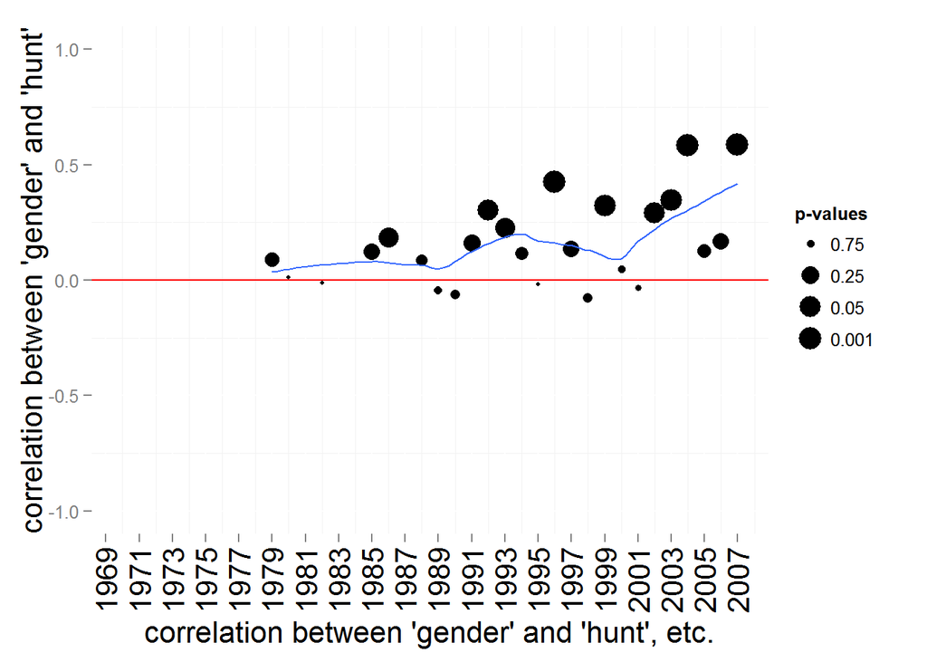

```r
JSTOR_2wordcor(unpack1grams,"gender",c("hunt","hunter","gatherer","gather","role","division","labor"), span = 0.5, yearfrom = 1970, yearto = 2007) +
  xlab("correlation between 'gender' and 'hunt', etc.") +
   theme(axis.title.x = element_text(size = 16, colour = 'black'),
         axis.title.y = element_text(size = 16, colour = 'black'),
         axis.text.x  = element_text(angle = 90, vjust = 0.5, size = 16, colour = 'black'))
```

```r
  xlab("correlation between 'gender' and 'hunt', etc.")
```

```
## $x
## [1] "correlation between 'gender' and 'hunt', etc."
##
## attr(,"class")
## [1] "labels"
```

```r
ggsave("figure/2words_gender_labor.png")
ggsave("figure/2words_gender_labor.svg")
```

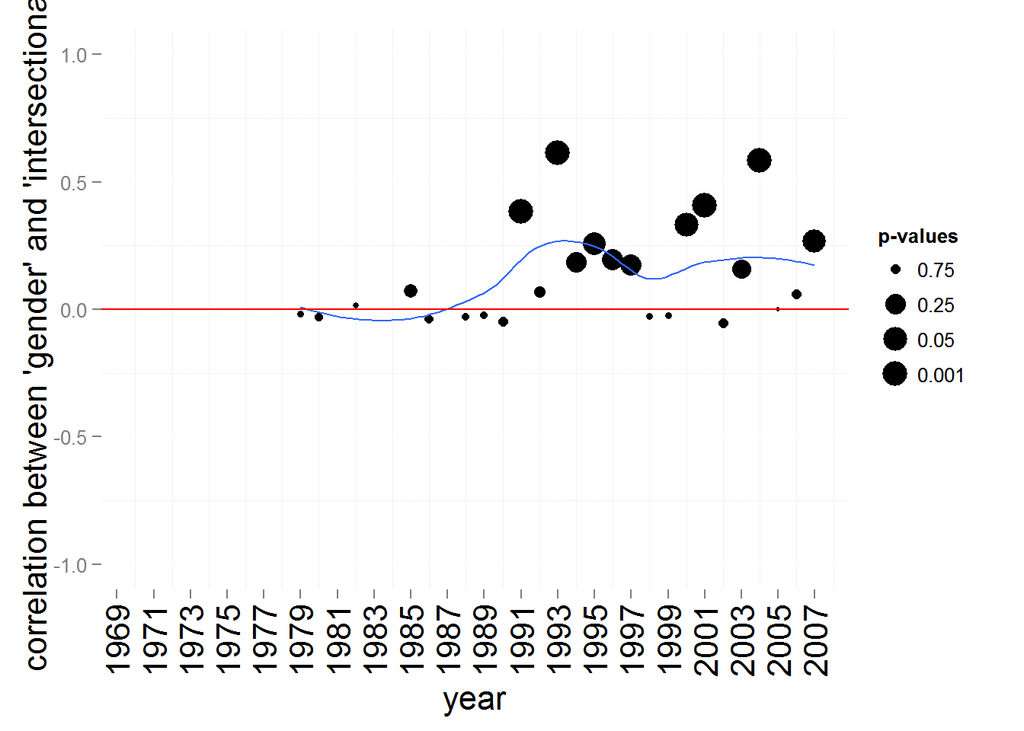

```r
JSTOR_2wordcor(unpack1grams,"gender",c("intersectionality","race","queer","identity","intersectional","sexuality"), span = 0.6, yearfrom = 1970, yearto = 2007) +
  theme(axis.title.x = element_text(size = 16, colour = 'black'),
         axis.title.y = element_text(size = 16, colour = 'black'),
         axis.text.x  = element_text(angle = 90, vjust = 0.5, size = 16, colour = 'black'))
```

```r
ggsave("figure/2words_gender_intersect.png")
ggsave("figure/2words_gender_intersect.svg")
```

### Some summary statistics on the words “gender”, “feminist”, and “feminism”

```r
feminism <- as.matrix(unpack1grams$wordcounts[,c("gender", "feminist", "feminism")])
```

The total count of these words is 1491, 218, 47.

The number of articles containing these words is 253

```r
# total count for each word?
no_gen_articles <- subset(feminism, feminism[,1] >0)
count_gender_articles <- length(no_gen_articles[,1]) # number of articles containing "gender"

no_feminist_articles <- subset(feminism, feminism[,2] >0)
count_feminism_articles <- length(no_feminist_articles[,2]) # number of articles containing "feminism"

no_feminism_articles <- subset(feminism, feminism[,3] >0)
count_feminist_articles <- length(no_feminism_articles[,3]) # number of articles containing "feminist"

# percent of articles containing 'gender' that also contain feminis*
gender_and_fem <- round((count_feminism_articles + count_feminist_articles) / count_gender_articles * 100, 0)

# this number rises to what after 1984?
## first subset the data to 1984 and later...
bibliodata <- data.frame(doi = unpack1grams$bibliodata[ ,'x'],
                         year = as.numeric(unpack1grams$bibliodata[ ,'year']),
                         stringsAsFactors = FALSE)
feminism <- data.frame(feminism)
feminism$doi <- rownames(feminism)
feminism_year <- merge(feminism, bibliodata, by =  'doi')
after_1984 <- feminism_year[feminism_year$year %in% 1982:1987, ]
## now compute percentage again...
after_1984_colsums <- data.frame(t(colSums(after_1984 != 0)))
after_1984_gender_and_fem <- round((after_1984_colsums$feminist + after_1984_colsums$feminism) / after_1984_colsums$gender * 100, 0)
```

Articles containing “gender”: 195

Feminism appears in 30% of publications on gender; this number rises to 50% for articles published during 1982-7

### Some summary statistics on the corpus used here

```r
journal_names <- gsub("\t", "", unique(unpack1grams$bibliodata$author)) # colnames are offset!
number_of_journals <- length(journal_names)
number_of_articles <- length(unique(unpack1grams$bibliodata$doi)) # colnames are offset!
```

The names of the journals in this corpus are American Antiquity

The number of journals is 1

The total number of articles is 4023

### Cluster analyses of articles containing the word ‘gender’

```r
# these analyses were rather slow on my computer!
# subset to get only articles that have the word 'gender'
nouns <- JSTOR_dtmofnouns(unpack1grams, word = "gender", sparse = 1, POStag = TRUE)
# do cluster analysis
gender_cluster <- JSTOR_clusterbywords(nouns, "gender", f = 0.01)
gender_cluster
```

[output not shown]